# EDA-82 (Story 2): What the Three Frames Together Say

Synthesising model-1, model-2, and model-3, and naming what comes next

Author

Analysis Team

Published

August 3, 2026

# Mission of `eda-82`

Three modelling reports are complete. `model-1` applied a penalty to 48 candidate predictors across all workers and refit what survived. `model-2` repeated the procedure inside each of 17 chronic-condition subgroups. `model-3` repeated it inside each sex and then refit both strata on a common term list so the two could be compared. Each report answers its own question well. None of them answers the question a reader actually brings: **taken together, what do these say about the role chronic conditions play in predicting days of missed work?**

That is this report. Where eda-81 explained *how* the primary model was built — what the penalty does, what the four specifications are — `eda-82` asks *what it means*, and is equally concerned with marking where the evidence runs out.

**This report fits nothing**

Every number here was computed by `model-1`, `model-2`, or `model-3` and written to disk by them. `eda-82` opens no analytic parquet, calls no `glmnet`, and calls no `MASS::glm.nb`. It reads sixteen files, joins them on a common term key, and reasons about them. If a number here disagrees with the number in its source report, the fault is in this report’s joining, and the provenance audit in Output out1 is where to look first.

**Research questions:**

1. What survives all three cuts of the data, and which predictors appear in only one frame?
2. How much of the variation in days absent do these models actually explain, and what does the gap between a 10-term and an 81-term model tell us about the ceiling of this design?
3. Does the condition-specific view add anything the pooled view does not already carry, or does subgroup selection mostly track subgroup size?
4. Where do the sexes genuinely differ in the association between a condition and days absent, as opposed to differing only in which terms the penalty happened to retain?
5. What substantive claim can this body of evidence currently support, stated at the strength the evidence permits and no higher?
6. What would the next round buy?

# Environment

**Packages used in the current report**

```r
library(magrittr)
library(ggplot2)
library(dplyr)
library(tidyr)
library(forcats)
library(purrr)
library(tibble)
library(scales)
library(fs)
library(kableExtra)
requireNamespace("readr", quietly = TRUE)
requireNamespace("knitr", quietly = TRUE)
requireNamespace("cowplot", quietly = TRUE)
requireNamespace("ggrepel", quietly = TRUE)
```

**Project functions, Alberta visual identity colours, and the shared candidate registry**

```r
base::source("./scripts/common-functions.R")
base::source("./scripts/graphing/graph-presets.R")

# The same registry model-1, model-2, and model-3 source. Sourcing it, rather
# than restating the labels here, is what keeps this report from drifting away
# from the three it synthesises.
base::source("./scripts/modeling/candidate-registry.R")
```

**Paths to sixteen upstream artifacts, the frame grid, and local display decisions**

```r
local_root    <- "./analysis/eda-82/"
local_data    <- paste0(local_root, "data-local/")
prints_folder <- paste0(local_root, "prints/")

for (folder in c(local_data, prints_folder)) {
  if (!fs::dir_exists(folder)) { fs::dir_create(folder, recurse = TRUE) }
}

# Upstream artifacts. Every one of these is a file another report wrote.
path_m1_nb          <- "./analysis/model-1/data-local/nb-coefficients.csv"
path_m1_compare     <- "./analysis/model-1/data-local/model-comparison.csv"
path_m1_cvsum       <- "./analysis/model-1/data-local/cv-performance-summary.csv"
path_m1_selmatrix   <- "./analysis/model-1/data-local/selection-matrix.csv"

path_m2_nb          <- "./analysis/model-2/data-local/nb-coefficients.csv"
path_m2_inventory   <- "./analysis/model-2/data-local/condition-inventory.csv"
path_m2_comorbid    <- "./analysis/model-2/data-local/comorbidity-overlap.csv"
path_m2_counts      <- "./analysis/model-2/data-local/selection-counts.csv"
path_m2_recurrence  <- "./analysis/model-2/data-local/term-recurrence.csv"

path_m3_union       <- "./analysis/model-3/data-local/union-coefficients.csv"
path_m3_het         <- "./analysis/model-3/data-local/sex-heterogeneity.csv"
path_m3_strata      <- "./analysis/model-3/data-local/stratum-inventory.csv"
path_m3_nb          <- "./analysis/model-3/data-local/nb-coefficients.csv"
path_m3_compare     <- "./analysis/model-3/data-local/model-comparison.csv"
path_m3_cvsum       <- "./analysis/model-3/data-local/cv-performance-summary.csv"
path_m3_selmatrix   <- "./analysis/model-3/data-local/selection-matrix.csv"

upstream_paths <- c(
  "model-1 : NB coefficients"        = path_m1_nb,
  "model-1 : model comparison"       = path_m1_compare,
  "model-1 : CV summary"             = path_m1_cvsum,
  "model-1 : selection matrix"       = path_m1_selmatrix,
  "model-2 : NB coefficients"        = path_m2_nb,
  "model-2 : condition inventory"    = path_m2_inventory,
  "model-2 : comorbidity overlap"    = path_m2_comorbid,
  "model-2 : selection counts"       = path_m2_counts,
  "model-2 : term recurrence"        = path_m2_recurrence,
  "model-3 : union coefficients"     = path_m3_union,
  "model-3 : sex heterogeneity"      = path_m3_het,
  "model-3 : stratum inventory"      = path_m3_strata,
  "model-3 : NB coefficients"        = path_m3_nb,
  "model-3 : model comparison"       = path_m3_compare,
  "model-3 : CV summary"             = path_m3_cvsum,
  "model-3 : selection matrix"       = path_m3_selmatrix
)

# Local decision 1. Each frame is represented by the specification its own
# report designated primary. model-2 reversed the penalty rule locally (its
# decision 25) because lambda.1se returns an empty selection in seven of the
# seventeen subgroups. That reversal is restated wherever the frames are
# compared, never silently absorbed.
frame_specs <- tibble::tribble(
  ~frame,               ~report,   ~primary_spec, ~primary_rule,
  "Pooled",             "model-1", "model_1",     "lambda.1se",
  "Condition-specific", "model-2", "spec_min",    "lambda.min",
  "Sex-stratified",     "model-3", "model_1",     "lambda.1se"
)

m1_primary_spec <- frame_specs$primary_spec[frame_specs$report == "model-1"]
m2_primary_spec <- frame_specs$primary_spec[frame_specs$report == "model-2"]
m3_primary_spec <- frame_specs$primary_spec[frame_specs$report == "model-3"]

# Local decision 4. Kish is the widest of the three lower bounds on the design
# effect, so quoting it is the least likely to overstate precision.
interval_variant <- "Kish"

strata_levels <- c("Female", "Male")

# The traced term for the Data Context section. Chosen because it is retained in
# all three frames, which is exactly what makes it useful as a worked example.
traced_term <- "Migraine: Yes"

n_conditions_total <- 17L

domain_levels <- c("Exposure", "Predisposing", "Facilitating", "Needs", "Survey design")

domain_colours <- c(
  "Exposure"      = abcol[["magenta"]],
  "Predisposing"  = abcol[["blue"]],
  "Facilitating"  = abcol[["green"]],
  "Needs"         = abcol[["brown"]],
  "Survey design" = abcol[["grey"]]
)

frame_colours <- c(
  "Pooled" = abcol[["grey"]],
  "Female" = abcol[["magenta"]],
  "Male"   = abcol[["blue"]]
)

retention_colours <- c(
  "retained"     = abcol[["green"]],
  "not retained" = "grey88"
)

heterogeneity_colours <- c(
  "both"        = abcol[["grey"]],
  "female only" = abcol[["magenta"]],
  "male only"   = abcol[["blue"]],
  "neither"     = "grey75"
)

# Relative widths of the two g1 panels. The left panel carries the row labels.
g1_panel_widths <- c(left = 1.00, right = 0.42)
```

**The term-key reconstruction, interval formatters, and a table printer**

```r
# Render a data frame as styled HTML for Quarto, or plainly for console use.
print_table <- function(data, caption, align = NULL, scroll_height = NULL) {
  if (is.null(scroll_height) && nrow(data) > 25) scroll_height <- "600px"
  boxed <- data %>%
    knitr::kable(
      format = "html", caption = caption, escape = FALSE,
      align = align, row.names = FALSE
    ) %>%
    kableExtra::kable_styling(
      bootstrap_options = c("striped", "hover", "condensed"), full_width = FALSE
    )
  boxed <- if (is.null(scroll_height)) {
    kableExtra::scroll_box(boxed, width = "100%")
  } else {
    kableExtra::scroll_box(boxed, width = "100%", height = scroll_height)
  }
  cat(as.character(boxed))
  invisible(data)
}

# Local decision 2. model-2 and model-3 persist a `term` column built exactly
# this way. Reconstructing the same string for model-1 makes all three joinable
# without a lookup table that could drift out of step.
make_term <- function(variable_label, level) {
  level <- ifelse(is.na(level), "", as.character(level))
  paste0(variable_label, ifelse(level == "", "", paste0(": ", level)))
}

# Format a rate ratio with its interval in one cell.
fmt_ratio <- function(estimate, low, high, digits = 2) {
  ifelse(
    is.na(estimate), "",
    sprintf(paste0("%.", digits, "f (%.", digits, "f-%.", digits, "f)"),
            estimate, low, high)
  )
}

fmt_p <- function(p, digits = 4) {
  ifelse(is.na(p), "",
         ifelse(p < 0.0001, "&lt;0.0001", sprintf(paste0("%.", digits, "f"), p)))
}

# Map a model label to the role its report assigned it. model-3's CV summary
# does not carry `role`; model-1's does. Deriving it once keeps the two joinable.
role_of <- function(model_label) {
  dplyr::case_when(
    model_label == "Model 1" ~ "Primary",
    model_label == "Model 2" ~ "Secondary",
    TRUE                     ~ "Sensitivity"
  )
}
```

# Data

**Read the sixteen artifacts model-1, model-2, and model-3 persisted**

```r
# Sixteen files, three reports, zero re-estimation.
m1_nb        <- readr::read_csv(path_m1_nb,        show_col_types = FALSE)
m1_compare   <- readr::read_csv(path_m1_compare,   show_col_types = FALSE)
m1_cvsum     <- readr::read_csv(path_m1_cvsum,     show_col_types = FALSE)
m1_selmatrix <- readr::read_csv(path_m1_selmatrix, show_col_types = FALSE)

m2_nb        <- readr::read_csv(path_m2_nb,         show_col_types = FALSE)
m2_inventory <- readr::read_csv(path_m2_inventory,  show_col_types = FALSE)
m2_comorbid  <- readr::read_csv(path_m2_comorbid,   show_col_types = FALSE)
m2_counts    <- readr::read_csv(path_m2_counts,     show_col_types = FALSE)
m2_recur     <- readr::read_csv(path_m2_recurrence, show_col_types = FALSE)

m3_union     <- readr::read_csv(path_m3_union,     show_col_types = FALSE)
m3_het       <- readr::read_csv(path_m3_het,       show_col_types = FALSE)
m3_strata    <- readr::read_csv(path_m3_strata,    show_col_types = FALSE)
m3_nb        <- readr::read_csv(path_m3_nb,        show_col_types = FALSE)
m3_compare   <- readr::read_csv(path_m3_compare,   show_col_types = FALSE)
m3_cvsum     <- readr::read_csv(path_m3_cvsum,     show_col_types = FALSE)
m3_selmatrix <- readr::read_csv(path_m3_selmatrix, show_col_types = FALSE)
```

**Type coercion and key construction only — nothing is recomputed**

```r
# Type coercion and key construction only. Nothing is recomputed.

# model-1 does not persist a `term` column; the other two do. Build it.
m1_nb <- m1_nb %>%
  filter(column != "(Intercept)") %>%
  mutate(
    term   = make_term(variable_label, level),
    domain = factor(domain, levels = domain_levels)
  )

m2_nb <- m2_nb %>%
  filter(column != "(Intercept)") %>%
  mutate(domain = factor(domain, levels = domain_levels))

m3_nb <- m3_nb %>%
  filter(column != "(Intercept)") %>%
  mutate(
    domain  = factor(domain, levels = domain_levels),
    stratum = factor(stratum, levels = strata_levels)
  )

m3_union <- m3_union %>%
  filter(column != "(Intercept)") %>%
  mutate(
    domain  = factor(domain, levels = domain_levels),
    stratum = factor(stratum, levels = strata_levels)
  )

m3_het <- m3_het %>%
  mutate(
    domain      = factor(domain, levels = domain_levels),
    retained_in = factor(retained_in, levels = names(heterogeneity_colours))
  )

# The three frames, reduced to the terms their own primary specification kept.
pooled_terms <- m1_nb %>%
  filter(spec_id == m1_primary_spec) %>%
  select(term, variable, level, domain,
         rr_pooled = rate_ratio, lo_pooled = ci_low_kish, hi_pooled = ci_high_kish,
         p_pooled = p_robust)

stratum_terms <- m3_nb %>%
  filter(spec_id == m3_primary_spec) %>%
  distinct(stratum, term) %>%
  mutate(retained = TRUE) %>%
  tidyr::pivot_wider(names_from = stratum, values_from = retained, values_fill = FALSE)

for (this_stratum in strata_levels) {
  if (!this_stratum %in% names(stratum_terms)) stratum_terms[[this_stratum]] <- FALSE
}

# Local decision 5. The recurrence count is what model-2 itself persisted.
condition_breadth <- m2_recur %>%
  rename(n_conditions = n_conditions)
```

```
Artifacts read: 16
```

```
Models re-fitted: 0
```

```
Pooled primary model terms      : 10
```

```
Female primary model terms      : 9
```

```
Male primary model terms        : 8
```

```
Union model terms (both strata) : 10
```

```
Condition subgroups fitted      : 17
```

```
Distinct terms across subgroups : 86
```

# Data Context

For complete data documentation, see the Data Primer. This report’s unit of analysis is not a respondent but a **model term**, so the context below describes the artifacts and the terms rather than the survey.

## Which artifact feeds which conclusion

The unit of analysis in this report is not a respondent but a model term. This table states which upstream file supplies which artifact, and at what grain each file is stored. Every row is a file another report wrote; eda-82 writes none of them.

| Artifact | Frame | Grain | Used by |
| --- | --- | --- | --- |
| model-1 nb-coefficients.csv | Pooled | term x specification | t2, t3, g1, g11 |
| model-1 model-comparison.csv | Pooled | specification | t3 |
| model-1 cv-performance-summary.csv | Pooled | specification x CV variant | t3, g2 |
| model-2 nb-coefficients.csv | Condition-specific | term x condition x rule | t4 |
| model-2 condition-inventory.csv | Condition-specific | condition | t4, g3 |
| model-2 comorbidity-overlap.csv | Condition-specific | condition | t4 |
| model-2 selection-counts.csv | Condition-specific | condition x rule | t4, g3 |
| model-2 term-recurrence.csv | Condition-specific | term | g1, t2 |
| model-3 union-coefficients.csv | Sex-stratified | term x stratum | g11, t5 |
| model-3 sex-heterogeneity.csv | Sex-stratified | term | t5, g4 |
| model-3 stratum-inventory.csv | Sex-stratified | stratum | t1 |
| model-3 nb-coefficients.csv | Sex-stratified | term x stratum x specification | g1, t2 |
| model-3 model-comparison.csv | Sex-stratified | stratum x specification | t3 |
| model-3 cv-performance-summary.csv | Sex-stratified | stratum x spec x CV variant | t3, g2 |
| model-3 selection-matrix.csv | Sex-stratified | variable | t5 |

## A single term, traced through three frames

Where a data primer would show one respondent, this report shows one term. `Migraine: Yes` is a useful specimen precisely because it appears everywhere: the pooled model kept it, both sex strata kept it, and eleven of the seventeen condition subgroups kept it.

Read the table below carefully, because the three blocks answer three different questions. The pooled row says how much more absence is associated with migraine among workers generally. The two stratum rows say the same thing within each sex. The condition rows say something narrower and easily misread: *among people who already have some other named condition*, how much more absence is associated with also having migraine. A migraine estimate inside the diabetes subgroup is not an estimate about diabetes.

One term, **Migraine: Yes**, as it appears in each of the three frames. The pooled row is an estimate across all workers. The two stratum rows come from the union model, the only place a female and a male estimate for the same term are both present. The condition rows are the same term estimated inside a subgroup defined by a different condition, so they answer a narrower question: among people who already have condition X, how much more absence is associated with also having a migraine.

| Frame | Subset | n | Rate ratio | Interval |
| --- | --- | --- | --- | --- |
| Pooled (model-1, Model 1) | All workers | NA | 1.63 (1.41-1.87) | Kish |
| Sex-stratified (model-3, union) - Female | Female workers | NA | 1.41 (1.20-1.64) | Kish |
| Sex-stratified (model-3, union) - Male | Male workers | NA | 1.84 (1.40-2.42) | Kish |
| Condition-specific (model-2, permissive) | Workers with back problems | 9,044 | 1.44 (1.14-1.83) | Kish |
| Condition-specific (model-2, permissive) | Workers with hypertension | 7,017 | 1.66 (1.10-2.50) | Kish |
| Condition-specific (model-2, permissive) | Workers with arthritis | 6,552 | 1.15 (0.83-1.59) | Kish |
| Condition-specific (model-2, permissive) | Workers with asthma | 3,853 | 1.45 (1.02-2.05) | Kish |
| Condition-specific (model-2, permissive) | Workers with mood disorder | 3,296 | 1.26 (0.95-1.68) | Kish |
| Condition-specific (model-2, permissive) | Workers with anxiety disorder | 2,670 | 1.09 (0.77-1.55) | Kish |
| Condition-specific (model-2, permissive) | Workers with diabetes | 2,329 | 1.85 (0.89-3.87) | Kish |
| Condition-specific (model-2, permissive) | Workers with heart disease | 1,364 | 1.67 (0.78-3.58) | Kish |
| Condition-specific (model-2, permissive) | Workers with multiple chemical sensitivities | 1,279 | 1.42 (0.88-2.29) | Kish |
| Condition-specific (model-2, permissive) | Workers with stomach / intestinal ulcer | 1,123 | 1.76 (1.00-3.10) | Kish |
| Condition-specific (model-2, permissive) | Workers with copd | 932 | 1.10 (0.50-2.41) | Kish |

## The shape of every subset that was modelled

The shape of every subset any of the three frames modelled. Read the last two columns together: subgroups differ in how often anyone missed work at all, and in how many days those who did missed. The two move together but not in lockstep, which is what makes the negative binomial’s separate handling of frequency and magnitude worth having.

| Frame | Subset | n | Non-zero share | Mean days |
| --- | --- | --- | --- | --- |
| Condition-specific | Back problems | 9,044 | 38.8% | 2.13 |
| Condition-specific | Hypertension | 7,017 | 30.5% | 1.68 |
| Condition-specific | Arthritis | 6,552 | 35.4% | 2.32 |
| Condition-specific | Migraine | 5,162 | 45.1% | 2.43 |
| Condition-specific | Asthma | 3,853 | 40.8% | 1.95 |
| Condition-specific | Mood disorder | 3,296 | 50.8% | 3.37 |
| Condition-specific | Anxiety disorder | 2,670 | 48.9% | 2.72 |
| Condition-specific | Bowel disorder | 2,372 | 46.1% | 2.70 |
| Condition-specific | Diabetes | 2,329 | 32.4% | 1.80 |
| Condition-specific | Heart disease | 1,364 | 32.5% | 2.34 |
| Condition-specific | Multiple chemical sensitivities | 1,279 | 45.3% | 2.44 |
| Condition-specific | Stomach / intestinal ulcer | 1,123 | 41.7% | 2.84 |
| Condition-specific | COPD | 932 | 42.2% | 3.30 |
| Condition-specific | Fibromyalgia | 590 | 46.1% | 2.71 |
| Condition-specific | Cancer | 559 | 44.4% | 3.57 |
| Condition-specific | Chronic fatigue syndrome | 438 | 52.5% | 4.58 |
| Condition-specific | Stroke | 187 | 42.2% | 2.74 |
| Sex-stratified | Male | 24,659 | 25.9% | 1.08 |
| Sex-stratified | Female | 24,273 | 35.5% | 1.53 |

# Part I: The Three Frames

## Table t1: what each report asked

Table t1: the three frames. Note the last column. model-1 and model-3 both designate the parsimonious rule primary; model-2 reverses it (its decision 25) because at subgroup scale the parsimonious rule returns an empty selection in seven of the seventeen conditions. This asymmetry is the single most important caveat on every cross-frame comparison that follows: a term retained in many subgroups under a permissive rule is not evidence of the same strength as a term retained in the pooled model under a parsimonious one.

| Frame | Report | Sections | Question | Models fitted | Analytic n | Primary rule |
| --- | --- | --- | --- | --- | --- | --- |
| Pooled | model-1 | 5.4 - 5.6 | Across all workers, which predictors survive a penalty applied to all 48 candidates at once? | 4 specifications | 48,932 | lambda.1se |
| Condition-specific | model-2 | 5.7 - 5.8 | Within the workers who have a given chronic condition, which predictors survive the same penalty? | 17 conditions x 2 rules = 34 | 187 to 9,044 per subgroup | lambda.min |
| Sex-stratified | model-3 | 5.9 - 5.10 | Within each sex separately, which predictors survive the same penalty, and do the two agree? | 2 strata x 4 specifications = 8, plus 1 union model per stratum | 24,273 female / 24,659 male | lambda.1se |

**The three frames do not share a penalty rule**

`model-1` and `model-3` designate `lambda.1se` primary — the parsimonious rule, which keeps the smallest model statistically indistinguishable from the best. `model-2` reverses this locally (its decision 25) because at subgroup scale the parsimonious rule finds nothing it is confident enough to keep in seven of the seventeen conditions.

The reversal was correct. But it means the frames are not evidentially interchangeable: **a term retained in eleven subgroups under a permissive rule is not evidence of the same strength as a term retained in the pooled model under a parsimonious one.** Every cross-frame comparison in this report is annotated where it crosses that boundary.

## Output out1: provenance

```
PROVENANCE AUDIT - eda-82 reads, and only reads
```

```
model-1 : NB coefficients             173 rows   OK        2026-08-02 17:07
model-1 : model comparison              4 rows   OK        2026-08-02 17:07
model-1 : CV summary                    8 rows   OK        2026-08-02 17:10
model-1 : selection matrix             49 rows   OK        2026-08-02 17:06
model-2 : NB coefficients             810 rows   OK        2026-08-03 04:25
model-2 : condition inventory          17 rows   OK        2026-08-03 04:24
model-2 : comorbidity overlap          16 rows   OK        2026-08-03 04:24
model-2 : selection counts             34 rows   OK        2026-08-03 04:25
model-2 : term recurrence              86 rows   OK        2026-08-03 04:25
model-3 : union coefficients           20 rows   OK        2026-08-03 10:29
model-3 : sex heterogeneity            10 rows   OK        2026-08-03 10:29
model-3 : stratum inventory             2 rows   OK        2026-08-03 10:28
model-3 : NB coefficients             313 rows   OK        2026-08-03 10:29
model-3 : model comparison              8 rows   OK        2026-08-03 10:29
model-3 : CV summary                   16 rows   OK        2026-08-03 10:29
model-3 : selection matrix             48 rows   OK        2026-08-03 10:28
```

```
Files read: 16   Files written by this report: 4 (all under data-local/)
```

```
glmnet calls: 0   MASS::glm.nb calls: 0   Parquet reads: 0
```

```
TERM KEY RECONSTRUCTION CHECK
```

```
                  source n_terms matched_to_model_1
 model-1 (reconstructed)      84                 84
     model-3 (persisted)      90                 81
     model-2 (persisted)      86                 72
```

```
Every term in the pooled primary model that also appears in model-3's
```

```
primary strata or model-2's subgroups matched on the reconstructed key.
```

```
An unmatched term would appear here as a shortfall in the last column.
```

`model-2` and `model-3` both persist a `term` column built as `variable_label: level`. `model-1` does not, so `eda-82` reconstructs the same string from `model-1`’s `variable_label` and `level` columns. The check above confirms the reconstruction: every term the pooled primary model retained also matched on the reconstructed key wherever it appears in the other two reports. Had a term failed to match, it would show as a shortfall in the last column and every downstream join would be suspect.

# Part II: What Converges

The central question. A predictor retained in one frame is a finding about that frame. A predictor retained in all of them is a finding about absenteeism.

## Graph g1: the convergent core

**Build the union row spine and the retention matrix**

```r
# The row spine is the union of every term the pooled primary model kept, every
# term either stratum's primary model kept, and every term retained in at least
# `breadth_floor` condition subgroups. The floor exists only to keep the graph
# legible; it is stated in the subtitle.
breadth_floor <- 8L

core_spine <- dplyr::bind_rows(
  pooled_terms %>% select(term, domain),
  m3_nb %>% filter(spec_id == m3_primary_spec) %>% select(term, domain),
  m2_nb %>%
    filter(spec_id == m2_primary_spec, !unstable) %>%
    semi_join(condition_breadth %>% filter(n_conditions >= breadth_floor), by = "term") %>%
    select(term, domain)
) %>%
  distinct(term, domain)

convergence <- core_spine %>%
  left_join(pooled_terms %>% transmute(term, Pooled = TRUE), by = "term") %>%
  left_join(stratum_terms, by = "term") %>%
  left_join(condition_breadth, by = "term") %>%
  mutate(
    Pooled       = tidyr::replace_na(Pooled, FALSE),
    Female       = tidyr::replace_na(Female, FALSE),
    Male         = tidyr::replace_na(Male, FALSE),
    n_conditions = tidyr::replace_na(n_conditions, 0L),
    n_frames     = as.integer(Pooled) + as.integer(Female) + as.integer(Male),
    breadth      = n_conditions / n_conditions_total,
    verdict = dplyr::case_when(
      Pooled & Female & Male                    ~ "all three frames",
      Pooled & (Female | Male)                  ~ "pooled and one stratum",
      Pooled                                    ~ "pooled only",
      Female & Male                             ~ "both strata, not pooled",
      Female | Male                             ~ "one stratum only",
      TRUE                                      ~ "condition subgroups only"
    )
  ) %>%
  arrange(desc(n_frames), desc(n_conditions), term) %>%
  mutate(term = forcats::fct_inorder(term) %>% forcats::fct_rev())

readr::write_csv(
  convergence %>% mutate(term = as.character(term)),
  paste0(local_data, "convergence.csv")
)

convergence_long <- convergence %>%
  select(term, domain, Pooled, Female, Male) %>%
  tidyr::pivot_longer(
    cols = c(Pooled, Female, Male),
    names_to = "frame", values_to = "kept"
  ) %>%
  mutate(
    frame = factor(frame, levels = c("Pooled", "Female", "Male")),
    kept  = ifelse(kept, "retained", "not retained")
  )
```

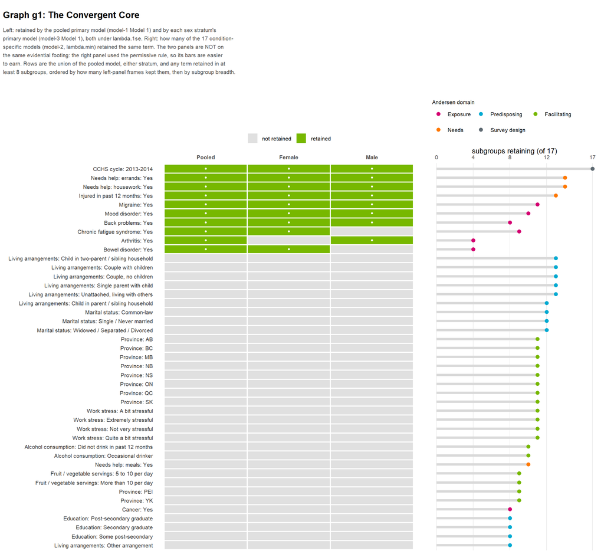

The left panel resolves into three tiers.

**Seven terms are retained in all three frames.** The survey cycle indicator, three chronic conditions (migraine, mood disorder, back problems), and three functional-need measures (injury in the past year, needing help with errands, needing help with housework). These are the terms that survived a parsimonious penalty applied three times to three different cuts of the data. They are the closest thing this body of work has to a robust finding.

**Three terms are retained pooled and in one stratum only.** Arthritis (pooled and male), chronic fatigue syndrome and bowel disorder (pooled and female). Part V asks whether these are genuine differences in association or artefacts of which term the penalty happened to grab.

**Everything below the green block is retained in *no* parsimonious model.** Living arrangements, marital status, province, work stress, alcohol, education — the whole predisposing and facilitating apparatus. Yet the right panel shows these terms being retained by eleven, twelve, thirteen of the seventeen condition subgroups.

**Why the bottom of the graph is not a contradiction**

The right panel used the permissive rule; the left used the parsimonious one. A permissive rule keeps everything whose held-out deviance improvement is positive, however small. So “retained in 13 of 17 subgroups” and “retained in 0 of 3 parsimonious models” are entirely consistent: these variables carry a small, consistent, real signal that the parsimonious rule declines to pay for.

That is not nothing. It is a statement that province and work stress and living arrangement are stably but weakly associated with absence — reliably detectable, not worth much predictively.

## Graph g11: the same core, estimated three ways

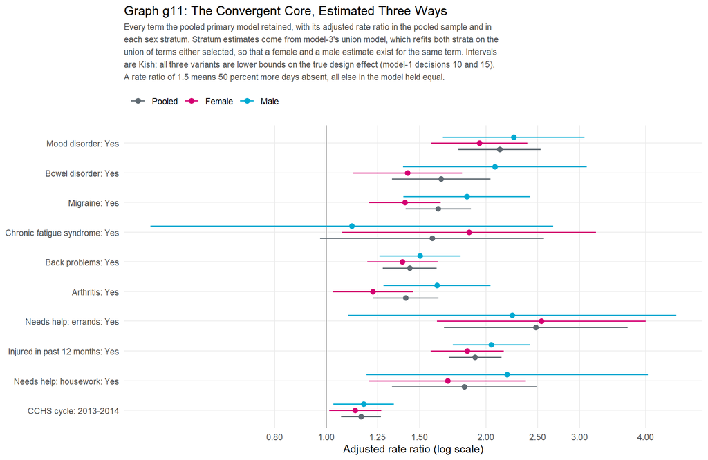

The horizontal axis is logarithmic because the models were fitted with a log link; equal distances are equal multiplicative factors, and a rate ratio of 1.5 means fifty per cent more days absent with everything else in the model held equal. `eda-81` sets out the reading rules for this scale in detail.

What the graph shows:

## Table t2: the core ledger

Table t2: the convergent core, term by term. Empty cells in the Pooled or stratum columns are not zeros; they mark a term for which that frame produced no estimate, because its selection step declined the variable. The Female and Male columns come from the union model, so they are populated for every term the pooled model kept even where a stratum’s own selection would have dropped it. Intervals are Kish.

| Domain | Term | Pooled RR | p (robust) | Female RR | Male RR | Strata keeping it | Subgroups keeping it | Verdict |
| --- | --- | --- | --- | --- | --- | --- | --- | --- |
| Survey design | CCHS cycle: 2013-2014 | 1.16 (1.07-1.27) | 0.0125 | 1.13 (1.01-1.27) | 1.18 (1.03-1.34) | both | 17 / 17 | all three frames |
| Needs | Needs help: errands: Yes | 2.48 (1.67-3.70) | <0.0001 | 2.54 (1.62-4.00) | 2.24 (1.10-4.56) | both | 14 / 17 | all three frames |
| Needs | Needs help: housework: Yes | 1.82 (1.33-2.49) | <0.0001 | 1.69 (1.20-2.38) | 2.19 (1.19-4.04) | both | 14 / 17 | all three frames |
| Needs | Injured in past 12 months: Yes | 1.91 (1.70-2.14) | <0.0001 | 1.84 (1.57-2.16) | 2.05 (1.73-2.42) | both | 13 / 17 | all three frames |
| Exposure | Migraine: Yes | 1.63 (1.41-1.87) | <0.0001 | 1.41 (1.20-1.64) | 1.84 (1.40-2.42) | both | 11 / 17 | all three frames |
| Exposure | Mood disorder: Yes | 2.12 (1.77-2.53) | <0.0001 | 1.94 (1.58-2.39) | 2.25 (1.66-3.06) | both | 10 / 17 | all three frames |
| Exposure | Back problems: Yes | 1.44 (1.28-1.61) | <0.0001 | 1.39 (1.19-1.62) | 1.50 (1.26-1.79) | both | 8 / 17 | all three frames |
| Exposure | Chronic fatigue syndrome: Yes | 1.58 (0.97-2.57) | 0.0034 | 1.86 (1.07-3.22) | 1.12 (0.47-2.68) | female only | 9 / 17 | pooled and one stratum |
| Exposure | Arthritis: Yes | 1.41 (1.22-1.63) | <0.0001 | 1.22 (1.03-1.46) | 1.62 (1.28-2.04) | male only | 4 / 17 | pooled and one stratum |
| Exposure | Bowel disorder: Yes | 1.65 (1.33-2.04) | <0.0001 | 1.42 (1.12-1.80) | 2.08 (1.40-3.09) | female only | 4 / 17 | pooled and one stratum |
| Predisposing | Living arrangements: Child in two-parent / sibling household |  |  |  |  | neither | 13 / 17 | condition subgroups only |
| Predisposing | Living arrangements: Couple with children |  |  |  |  | neither | 13 / 17 | condition subgroups only |
| Predisposing | Living arrangements: Couple, no children |  |  |  |  | neither | 13 / 17 | condition subgroups only |
| Predisposing | Living arrangements: Single parent with child |  |  |  |  | neither | 13 / 17 | condition subgroups only |
| Predisposing | Living arrangements: Unattached, living with others |  |  |  |  | neither | 13 / 17 | condition subgroups only |
| Predisposing | Living arrangements: Child in parent / sibling household |  |  |  |  | neither | 12 / 17 | condition subgroups only |
| Predisposing | Marital status: Common-law |  |  |  |  | neither | 12 / 17 | condition subgroups only |
| Predisposing | Marital status: Single / Never married |  |  |  |  | neither | 12 / 17 | condition subgroups only |
| Predisposing | Marital status: Widowed / Separated / Divorced |  |  |  |  | neither | 12 / 17 | condition subgroups only |
| Facilitating | Province: AB |  |  |  |  | neither | 11 / 17 | condition subgroups only |
| Facilitating | Province: BC |  |  |  |  | neither | 11 / 17 | condition subgroups only |
| Facilitating | Province: MB |  |  |  |  | neither | 11 / 17 | condition subgroups only |
| Facilitating | Province: NB |  |  |  |  | neither | 11 / 17 | condition subgroups only |
| Facilitating | Province: NS |  |  |  |  | neither | 11 / 17 | condition subgroups only |
| Facilitating | Province: ON |  |  |  |  | neither | 11 / 17 | condition subgroups only |
| Facilitating | Province: QC |  |  |  |  | neither | 11 / 17 | condition subgroups only |
| Facilitating | Province: SK |  |  |  |  | neither | 11 / 17 | condition subgroups only |
| Facilitating | Work stress: A bit stressful |  |  |  |  | neither | 11 / 17 | condition subgroups only |
| Facilitating | Work stress: Extremely stressful |  |  |  |  | neither | 11 / 17 | condition subgroups only |
| Facilitating | Work stress: Not very stressful |  |  |  |  | neither | 11 / 17 | condition subgroups only |
| Facilitating | Work stress: Quite a bit stressful |  |  |  |  | neither | 11 / 17 | condition subgroups only |
| Facilitating | Alcohol consumption: Did not drink in past 12 months |  |  |  |  | neither | 10 / 17 | condition subgroups only |
| Facilitating | Alcohol consumption: Occasional drinker |  |  |  |  | neither | 10 / 17 | condition subgroups only |
| Needs | Needs help: meals: Yes |  |  |  |  | neither | 10 / 17 | condition subgroups only |
| Facilitating | Fruit / vegetable servings: 5 to 10 per day |  |  |  |  | neither | 9 / 17 | condition subgroups only |
| Facilitating | Fruit / vegetable servings: More than 10 per day |  |  |  |  | neither | 9 / 17 | condition subgroups only |
| Facilitating | Province: PEI |  |  |  |  | neither | 9 / 17 | condition subgroups only |
| Facilitating | Province: YK |  |  |  |  | neither | 9 / 17 | condition subgroups only |
| Exposure | Cancer: Yes |  |  |  |  | neither | 8 / 17 | condition subgroups only |
| Predisposing | Education: Post-secondary graduate |  |  |  |  | neither | 8 / 17 | condition subgroups only |
| Predisposing | Education: Secondary graduate |  |  |  |  | neither | 8 / 17 | condition subgroups only |
| Predisposing | Education: Some post-secondary |  |  |  |  | neither | 8 / 17 | condition subgroups only |
| Predisposing | Living arrangements: Other arrangement |  |  |  |  | neither | 8 / 17 | condition subgroups only |

Empty cells in the pooled column are not zeros. They mark a term for which the pooled model produced no estimate, because its selection step declined the variable. The female and male columns are populated for every term the pooled model kept, because they come from `model-3`’s union model, which deliberately refits both strata on a shared term list for exactly this purpose.

# Part III: What the Models Explain

This is the part of the synthesis that is least comfortable and most important.

## Table t3: the explained-variance ledger

Table t3: what the models explain. Read the McFadden columns first and read them as what they are: a pseudo-R-squared on the log-likelihood scale, not a proportion of variance. Even so, the largest value anywhere in this table is under 0.04. Then read the Terms column against it. Going from the primary model to the largest sensitivity model multiplies the term count roughly eightfold and moves held-out discrimination by a few hundredths. Held-out columns come from the ‘fixed term set’ variant, in which the term list is held constant and only the coefficients are refit per fold.

| Frame | Subset | Model | Role | n | Terms | AIC | Theta | McFadden (in-sample) | McFadden (held-out) | C (in-sample) | C (held-out) | RMSE (held-out) |
| --- | --- | --- | --- | --- | --- | --- | --- | --- | --- | --- | --- | --- |
| Pooled | All workers | Model 1 | Primary | 48,932 | 10 | 121,536 | 0.182 | 0.0200 | 0.0193 | 0.613 | 0.613 | 4.021 |
| Pooled | All workers | Model 2 | Secondary | 48,932 | 15 | 120,557 | 0.193 | 0.0280 | 0.0266 | 0.632 | 0.630 | 3.978 |
| Pooled | All workers | Model 3 | Sensitivity | 48,932 | 67 | 120,593 | 0.193 | 0.0285 | 0.0205 | 0.652 | 0.640 | 4.228 |
| Pooled | All workers | Model 4 | Sensitivity | 48,932 | 81 | 119,715 | 0.204 | 0.0358 | 0.0266 | 0.665 | 0.653 | 4.460 |
| Sex-stratified | Female | Model 1 | Primary | 24,273 | 9 | 68,123 | 0.222 | 0.0196 | 0.0179 | 0.617 | 0.616 | 4.242 |
| Sex-stratified | Female | Model 2 | Secondary | 24,273 | 18 | 67,477 | 0.237 | 0.0291 | 0.0257 | 0.640 | 0.636 | 4.171 |
| Sex-stratified | Female | Model 3 | Sensitivity | 24,273 | 71 | 67,426 | 0.240 | 0.0314 | 0.0163 | 0.653 | 0.634 | 4.523 |
| Sex-stratified | Female | Model 4 | Sensitivity | 24,273 | 82 | 66,880 | 0.255 | 0.0395 | 0.0247 | 0.667 | 0.649 | 4.291 |
| Sex-stratified | Male | Model 1 | Primary | 24,659 | 8 | 54,348 | 0.151 | 0.0185 | 0.0177 | 0.601 | 0.601 | 3.703 |
| Sex-stratified | Male | Model 2 | Secondary | 24,659 | 16 | 53,856 | 0.161 | 0.0277 | 0.0247 | 0.621 | 0.618 | 4.028 |
| Sex-stratified | Male | Model 3 | Sensitivity | 24,659 | 57 | 53,873 | 0.162 | 0.0289 | 0.0177 | 0.631 | 0.618 | 4.133 |
| Sex-stratified | Male | Model 4 | Sensitivity | 24,659 | 53 | 53,514 | 0.170 | 0.0352 | 0.0252 | 0.645 | 0.633 | 4.692 |

## Graph g2: what the extra terms buy

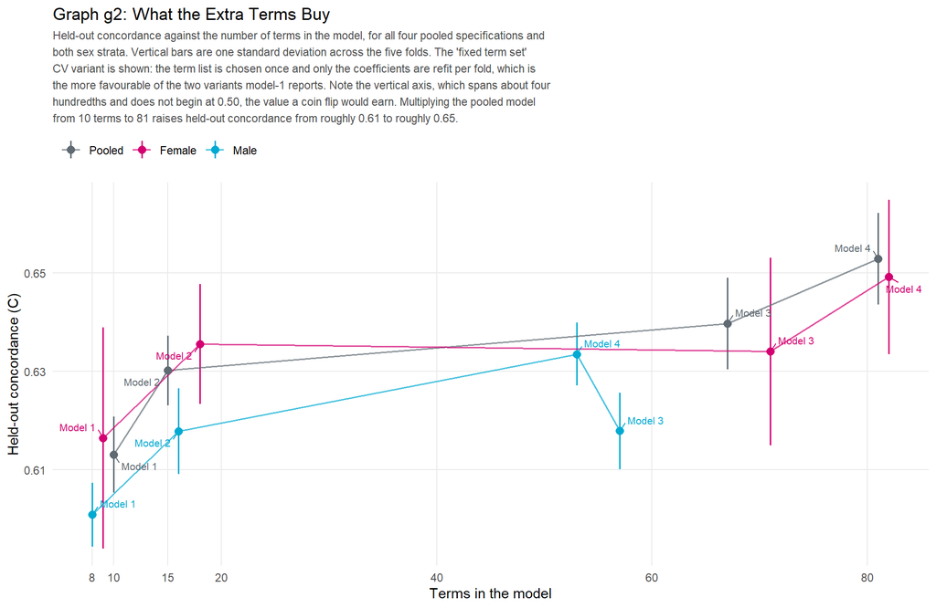

Three readings, in increasing order of consequence.

**The models discriminate modestly.** Held-out concordance runs from about 0.60 to about 0.65. A concordance of 0.50 is a coin flip and 1.00 is perfect ordering. Given two randomly chosen workers, the primary model correctly identifies which of the two missed more work about 61 per cent of the time.

**McFadden’s pseudo-$R^2$ is under 0.04 everywhere.** It is not a proportion of variance and must not be read as one, but on its own scale it is small: the fitted models improve the log-likelihood only slightly over an intercept-only model. Days of missed work are, in this data, overwhelmingly determined by something these 48 variables do not measure.

**Eightfold more terms buy four hundredths of concordance.** Model 1 carries 10 terms and reaches 0.613. Model 4 carries 81 and reaches 0.653. The 71 additional terms — the whole predisposing and facilitating apparatus, plus perceived health — improve held-out ordering by 0.04. This is the strongest evidence in the whole exercise that the constraint is not the model.

**What a low ceiling does and does not mean**

It does **not** mean the rate ratios are wrong. A predictor can carry a well-estimated, reproducible association and still explain little variation, because most of the variation is elsewhere. The intervals in Graph g11 are narrow for exactly this reason: 48,932 respondents estimate a moderate association precisely.

It **does** mean two things. First, these models are not prediction tools; nobody should use them to forecast an individual’s absence. Second, and more interesting scientifically: absence is dominated by within-person, within-episode, and within-workplace variation that a cross-sectional self-report of chronic condition status cannot reach. Table t6 lists the several ways one might reach it.

# Part IV: The Condition-Specific View

Seventeen models, one per chronic condition. The question this part asks is whether the differences among them are differences between conditions or differences between sample sizes.

## Table t4: the condition ledger

Table t4: the seventeen condition subgroups. The two rightmost numeric columns are the heart of the matter. Under the parsimonious rule the penalty returns an empty selection in seven subgroups; it can find nothing it is confident enough to keep. Under the permissive rule the same subgroups yield between 6 and 30 variables. The comorbidity columns explain why these seventeen rows are not seventeen independent findings: the subgroups overlap heavily, and the smallest ones overlap most.

| Condition | n | Prevalence | Any absence | Mean days | Other conditions (mean) | Has any other | Most common companion | Kept (permissive) | Kept (parsimonious) | Verdict |
| --- | --- | --- | --- | --- | --- | --- | --- | --- | --- | --- |
| Back problems | 9,044 | 18.5% | 38.8% | 2.13 | 1.36 | 66.1% | Arthritis (28.5%); Hypertension (19.6%) | 27 | 10 | fitted |
| Hypertension | 7,017 | 14.3% | 30.5% | 1.68 | 1.34 | 66.9% | Arthritis (27.4%); Back problems (25.2%) | 24 | 9 | fitted |
| Arthritis | 6,552 | 13.4% | 35.4% | 2.32 | 1.64 | 76.5% | Back problems (39.4%); Hypertension (29.4%) | 29 | 13 | fitted |
| Migraine | 5,162 | 10.5% | 45.1% | 2.43 | 1.40 | 65.3% | Back problems (31.2%); Arthritis (19.6%) | 30 | 7 | fitted |
| Asthma | 3,853 | 7.9% | 40.8% | 1.95 | 1.39 | 62.8% | Back problems (26.2%); Arthritis (19.9%) | 21 | 8 | fitted |
| Mood disorder | 3,296 | 6.7% | 50.8% | 3.37 | 1.93 | 80.2% | Anxiety disorder (33.7%); Back problems (32.5%) | 22 | 2 | fitted |
| Anxiety disorder | 2,670 | 5.5% | 48.9% | 2.72 | 1.95 | 81.8% | Mood disorder (41.6%); Back problems (31.9%) | 27 | 12 | fitted |
| Bowel disorder | 2,372 | 4.8% | 46.1% | 2.70 | 1.82 | 75.6% | Back problems (33.1%); Arthritis (27.1%) | 9 | 1 (empty) | fitted |
| Diabetes | 2,329 | 4.8% | 32.4% | 1.80 | 1.68 | 78.4% | Hypertension (51.5%); Arthritis (28.3%) | 18 | 1 (empty) | fitted |
| Heart disease | 1,364 | 2.8% | 32.5% | 2.34 | 1.87 | 81.7% | Hypertension (48.8%); Arthritis (29.1%) | 11 | 1 (empty) | fitted |
| Multiple chemical sensitivities | 1,279 | 2.6% | 45.3% | 2.44 | 2.18 | 82.6% | Back problems (38.5%); Arthritis (31.7%) | 23 | 4 | fitted |
| Stomach / intestinal ulcer | 1,123 | 2.3% | 41.7% | 2.84 | 2.12 | 80.9% | Back problems (37.8%); Arthritis (30.4%) | 7 | 1 (empty) | fitted |
| COPD | 932 | 1.9% | 42.2% | 3.30 | NA | NA | NA | 24 | 15 | fitted |
| Fibromyalgia | 590 | 1.2% | 46.1% | 2.71 | 2.87 | 90.7% | Arthritis (50.7%); Back problems (50.3%) | 11 | 5 | fitted |
| Cancer | 559 | 1.1% | 44.4% | 3.57 | 1.69 | 75.3% | Back problems (29.9%); Hypertension (28.4%) | 6 | 1 (empty) | fitted |
| Chronic fatigue syndrome | 438 | 0.9% | 52.5% | 4.58 | 3.26 | 92.7% | Back problems (47.7%); Arthritis (39.5%) | 10 | 1 (empty) | fitted, flagged small |
| Stroke | 187 | 0.4% | 42.2% | 2.74 | 2.47 | 87.7% | Hypertension (49.2%); Arthritis (33.7%) | 12 | 1 (empty) | fitted, flagged small |

## Graph g3: subgroup scale and selection yield

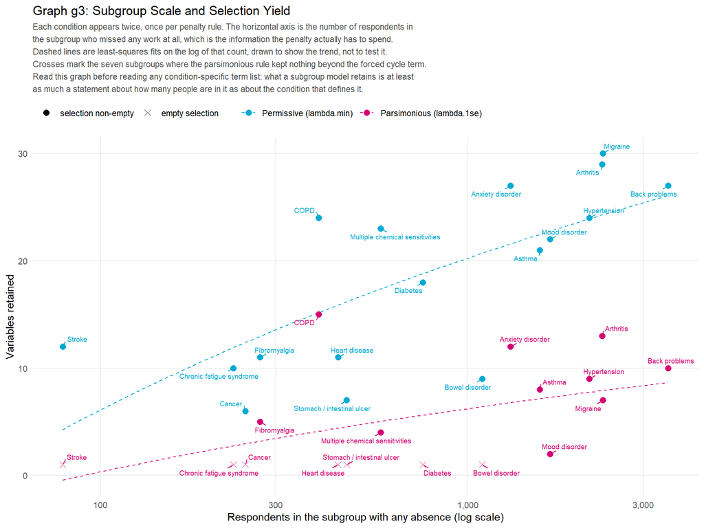

This has a direct interpretive consequence. Reading `model-2`’s condition-specific term lists as a claim about the conditions — “in diabetes, only these three things matter” — would be a mistake. In diabetes the penalty had 754 absentees to work with and could not confidently distinguish much. The term list is a statement about statistical power at least as much as about pathophysiology.

**The one clean exception**

Stroke sits well above the permissive trend line: 79 absentees, 12 variables retained. That is the opposite of what the trend predicts and is worth a look. With 187 respondents and 79 absentees, a permissive penalty on a wide design matrix is in the regime where selection is unstable rather than informative. `model-2` flags stroke and chronic fatigue syndrome as small-subgroup cases for this reason. This is a caution, not a finding.

## What the comorbidity columns do to the whole exercise

Table t4’s comorbidity block is easy to skim past and should not be. Between 63 and 93 per cent of the members of any condition subgroup carry at least one other named condition. Workers with fibromyalgia carry 2.9 other conditions on average; workers with chronic fatigue syndrome, 3.3.

This is the single most actionable methodological finding in this report, and it is what makes elastic net the first item on the roadmap.

# Part V: The Sex-Stratified View

Whether the two strata differ in *what they retain* is a fact about selection. Whether they differ in *the size of an association* is a fact about the world. Only the union model can speak to the second, because it refits both strata on a common term list so that a female and a male estimate exist for the same term.

## Table t5: the heterogeneity ledger

Table t5: the heterogeneity ledger, from model-3’s union model. The ratio column is female rate ratio divided by male rate ratio; a value below 1 means the association is stronger in men. The interval and p-value use the Wald standard error, because that is what model-3 computed and this report does not recompute (local decision 4). Ten terms are tested here without adjustment for multiplicity, so read the smallest p-values as the ones worth a follow-up design, not as established differences.

| Domain | Term | Female RR | Male RR | Ratio F / M | z | p (difference) | Selected in |
| --- | --- | --- | --- | --- | --- | --- | --- |
| Exposure | Arthritis: Yes | 1.22 (1.12-1.34) | 1.62 (1.43-1.83) | 0.76 (0.65-0.88) | -3.56 | 0.0004 | male only |
| Exposure | Migraine: Yes | 1.41 (1.30-1.52) | 1.84 (1.59-2.13) | 0.76 (0.65-0.90) | -3.15 | 0.0017 | both |
| Exposure | Bowel disorder: Yes | 1.42 (1.26-1.61) | 2.08 (1.68-2.57) | 0.69 (0.54-0.88) | -3.03 | 0.0025 | female only |
| Exposure | Chronic fatigue syndrome: Yes | 1.86 (1.40-2.47) | 1.12 (0.70-1.78) | 1.66 (0.96-2.87) | +1.83 | 0.0673 | female only |
| Needs | Injured in past 12 months: Yes | 1.84 (1.70-2.00) | 2.05 (1.87-2.24) | 0.90 (0.80-1.02) | -1.70 | 0.0894 | both |
| Exposure | Mood disorder: Yes | 1.94 (1.75-2.16) | 2.25 (1.91-2.65) | 0.86 (0.71-1.05) | -1.48 | 0.1382 | both |
| Needs | Needs help: housework: Yes | 1.69 (1.42-2.02) | 2.19 (1.58-3.04) | 0.77 (0.53-1.12) | -1.37 | 0.1701 | both |
| Exposure | Back problems: Yes | 1.39 (1.29-1.51) | 1.50 (1.37-1.65) | 0.93 (0.82-1.05) | -1.21 | 0.2258 | both |
| Survey design | CCHS cycle: 2013-2014 | 1.13 (1.07-1.20) | 1.18 (1.10-1.26) | 0.96 (0.88-1.06) | -0.77 | 0.4391 | both |
| Needs | Needs help: errands: Yes | 2.54 (2.01-3.21) | 2.24 (1.53-3.27) | 1.14 (0.73-1.77) | +0.56 | 0.5760 | both |

## Graph g4: where the sexes differ

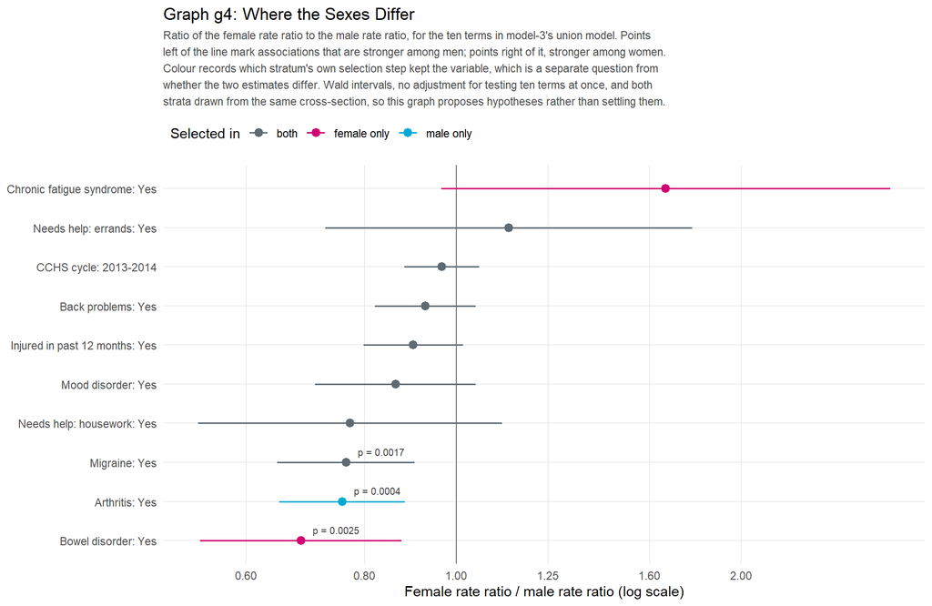

Three terms show a difference that clears conventional significance without correction for testing ten terms at once, and all three point the same way:

- **Arthritis** (ratio 0.76, $p$ = 0.0004): the association with absence is stronger among men.
- **Bowel disorder** (ratio 0.69, $p$ = 0.0025): stronger among men.
- **Migraine** (ratio 0.76, $p$ = 0.0017): stronger among men.

The remaining seven terms show no detectable difference.

**Selection disagreement is not the same as heterogeneity**

The colour coding makes a point the table cannot. Arthritis was kept by the **male** stratum’s own selection step and not the female one; bowel disorder by the **female** one and not the male. The *estimates* say the association is stronger in men in both cases. Selection and effect size are answering different questions, and reading a stratum’s term list as a claim about which conditions “matter for women” would invert the arthritis result.

This is the general hazard of stratified selection, and it is why `model-3` built the union model.

## An interpretation offered tentatively

A pattern in which several conditions carry a *larger* association with absence among men, while women have both higher overall absence (mean 1.53 days versus 1.08) and higher prevalence of most of these conditions, is consistent with a differential-threshold account: if women’s absence is driven by a broader set of causes — including caregiving and a wider range of conditions — then any single condition accounts for a smaller share of it. It is equally consistent with differential reporting, differential job type, or differential access to sick leave.

Nothing in this data adjudicates among those. The three significant ratios are worth a designed follow-up; they are not worth a mechanism in a manuscript.

# Part VI: What This Body of Evidence Currently Supports

Stating conclusions at the strength the evidence permits, and no higher.

**2. Mental health and pain conditions dominate the physical-disease conditions.** Mood disorder (2.12) is the largest single condition effect, and migraine (1.63), back problems (1.44), and bowel disorder (1.65) all survive while hypertension, diabetes, heart disease, and cancer do not. The conditions that predict absence are the ones that are episodic, painful, or psychological — not the ones that are chronic, managed, and asymptomatic between events.

**3. Functional limitation predicts absence at least as strongly as diagnosis.** Needing help with errands (2.48) and with housework (1.82), and injury in the past twelve months (1.91), are among the largest terms in the pooled model and are retained in every frame. A worker’s functional state carries information a diagnosis list does not.

**5. These predictors, collectively, account for very little of the variation in absence.** Held-out concordance around 0.61, McFadden under 0.04, and an eightfold increase in model size buying four hundredths of discrimination. This is the most robust finding in the report and the one most likely to be under-reported.

## Four claims the evidence does not support

**Not causation.** Condition status and days absent are reported in the same interview. A worker who missed thirty days is more likely to have consulted a physician and received a diagnosis. Every estimate here is an adjusted association on cross-sectional data, and no further modelling of these two cycles will change that.

**Not a prediction instrument.** A concordance of 0.61 is not a basis for individual forecasting, screening, or targeting.

**Not condition-specific mechanism.** The seventeen subgroup models overlap so heavily — 63 to 93 per cent of each subgroup carries another condition — that a term retained in the arthritis model is not cleanly a statement about arthritis.

## How this advances what is known

The literature on chronic conditions and work absence is large and mostly reports condition-by-condition associations from single-condition samples. This exercise contributes three things that design cannot.

**A common candidate set and a common penalty across seventeen conditions.** The condition-specific results are directly comparable to one another because they were produced by one procedure on one frame, rather than assembled from studies with different covariate sets.

**An explicit accounting of what the whole apparatus explains.** Very few papers in this area report held-out discrimination. Table t3 is a statement about the limits of the cross-sectional survey design that is useful independent of any individual rate ratio.

**A demonstration that functional limitation competes with diagnosis.** The activities-of-daily-living measures are retained in every frame and are as large as the largest condition. That is an argument for measuring function alongside diagnosis in absence research, and it is visible here only because both were offered to the same penalty on the same footing.

# Part VII: Next Lines of Inquiry

## Table t6: the roadmap

Table t6: next lines of inquiry. The Methodological rows change how the same data are analysed; the Substantive rows change what is asked of them. Read the last column as a triage: several rows are one script away, one requires a different data source, and one cannot be answered by this design at all. Nothing in this table is a result.

| Line | Kind | What it changes | What it would settle | What blocks it today |
| --- | --- | --- | --- | --- |
| Ridge (L2) on the full candidate set | Methodological | Shrinks every coefficient toward zero without setting any to zero, so no variable is discarded. | Whether the terms L1 dropped were genuinely uninformative or were merely the losers of a correlated pair. A ridge fit gives every candidate an estimate, and the ridge-versus-LASSO gap for a dropped te… | Nothing. `glmnet(alpha = 0)` on the existing design matrix; the pipeline already builds it. |
| Elastic net over a grid of alpha | Methodological | Interpolates between L1 and L2, so correlated predictors can enter together rather than one standing for the group. | Whether the seventeen chronic conditions behave as a correlated block. Under L1 the block is represented by its strongest member; under elastic net the block enters as a block. Given the comorbidity o… | Nothing, but the alpha grid needs its own cross-validation layer, which roughly multiplies runtime by the length of the grid. |
| Stepwise selection with an information criterion | Methodological | Replaces a continuous penalty with a discrete search over term subsets, scored by AIC or BIC. | Whether the term list is an artifact of the penalty family. Stepwise and LASSO fail in different directions; agreement between them is worth more than either alone. It also produces a nested sequence,… | Nothing technically. But stepwise inference is the least defensible of the four, so it should be run as a concordance check on LASSO and never reported as a primary result. |
| Regression trees and random forests | Methodological | Abandons the linear-in-log-mean form entirely; splits on thresholds and discovers interactions without being told to look for them. | Whether the low pseudo-R-squared in Table t3 is a limit of the data or a limit of the additive form. If a forest reaches the same held-out concordance as the ten-term model, the ceiling is the data. I… | Count outcomes need care: use Poisson-deviance splitting or model the two-part structure separately. Survey weights in forests are handled by resampling weight, which the absent bootstrap replicates m… |
| Two-part / hurdle decomposition | Methodological | Separates the decision to miss any work from the number of days missed, and models the two with different equations. | Whether chronic conditions raise the probability of any absence, lengthen absences once they begin, or both. Table t4 shows that non-zero share and mean days do not move together across subgroups, so … | Nothing. `pscl::hurdle` or a manual two-stage fit on the existing frame. The interpretive payoff is high relative to the cost. |
| Interaction terms tested rather than stratification | Methodological | Puts sex back into one model with explicit condition-by-sex product terms, instead of splitting the sample. | Whether the differences in Table t5 survive when both strata contribute to a common baseline. Stratification spends degrees of freedom on every nuisance parameter twice; an interaction test spends the… | Nothing. It is a strictly more powerful test of the same question and should probably accompany, not replace, the stratified presentation. |
| Multiple imputation of the 24 percent dropped | Methodological | Recovers the respondents complete-case filtering discarded, under a missing-at-random assumption. | Whether the analytic sample is representative. `model-1` documents a 24 percent loss to missingness; nothing so far establishes that the lost rows resemble the kept ones. This is currently the largest… | The missingness is partly structural: `has_family_doctor` is absent by design outside Ontario, and structural missingness must not be imputed. The imputation model needs the missingness taxonomy first… |
| Condition count and condition clusters as exposures | Substantive | Replaces seventeen binary indicators with a burden measure and with empirically derived condition clusters. | Whether absence tracks any particular diagnosis or simply the accumulation of morbidity. Table t4 shows respondents with chronic fatigue syndrome carry 3.3 other conditions on average; the current des… | Nothing. Both are derivable from the existing exposure block in one Ellis pass. |
| Severity, duration, and treatment status | Substantive | Adds within-condition gradients to a currently binary exposure. | Whether the modest rate ratios reflect a weak association or a diluted one. Every person with arthritis is currently one indicator, whether newly diagnosed and controlled or long-standing and disablin… | The PUMF carries little severity detail. This likely requires a different data source, which makes it the most expensive item on this list and possibly the most important. |
| Occupational and workplace context | Substantive | Treats the job, not only the worker, as a source of variation in absence. | Whether the same condition costs different numbers of days in different work. Work stress and occupation category recur across condition subgroups in Table t4’s companion recurrence data, which sugges… | The candidate registry already carries occupation, work stress, and schedule. What is missing is a hypothesis about how they interact with condition, which is a design question rather than a data one. |
| The direction of the association | Substantive | Asks whether conditions produce absence or absence produces diagnosis. | Nothing, within this design. Condition status and absence are reported in the same interview. This row exists to mark the boundary: every rate ratio in this report is an adjusted association, and no a… | Cross-sectional data. Resolving it requires longitudinal linkage or an administrative absence record, not a better estimator. |
| Between-cycle comparison as a stability check | Substantive | Uses the 2010-11 and 2013-14 cycles as two samples rather than one pooled sample. | Whether the retained term list is stable across independent draws from the same population. The cycle indicator is retained in every model in this report, which means the two cycles differ in level; n… | Nothing. It halves the sample per fit, which will thin the smaller condition subgroups past usefulness, but the pooled and stratified frames can both bear it. |

## Methodological expansion, in priority order

The roadmap table gives the full comparison. Four items deserve a sentence of argument here.

**Elastic net is the highest-value single change.** The comorbidity structure documented in Table t4 is exactly the situation in which L1 selection is known to misbehave: correlated predictors compete, one wins arbitrarily, and the rest are reported as eliminated. Ridge would give every candidate an estimate and reveal how much of the elimination was collinearity. Elastic net would let the condition block enter as a block. Running a grid over $\alpha$ and reporting the selection path as a function of $\alpha$ would convert the current binary retained/eliminated verdict into a graded one, which is a strictly more honest object.

**A two-part model is the highest-value change to the outcome side.** Table t4 shows that a subgroup’s non-zero share and its mean days do not move together. A single negative binomial averages two distinguishable processes: whether a worker misses any time at all, and how long the absence runs. Separating them would let the analysis say whether chronic conditions raise the *frequency* of absence, its *duration*, or both — a question the current results cannot address and that matters for policy, since the two have different remedies.

**Trees settle the ceiling question.** If a random forest, given the same 48 variables, reaches roughly the same held-out concordance as the ten-term negative binomial, then the ceiling in Table t3 belongs to the data and the additive form is not costing anything. If it clears that ceiling materially, there is interaction or threshold structure the current models cannot see, and the obvious place to look is condition-by-occupation and condition-by-sex. Either result is informative, which is unusual and makes this a good use of effort.

**Stepwise selection is worth running and not worth reporting as primary.** Its value is entirely as a concordance check: agreement between two selection procedures with different failure modes is worth more than either alone. Its inferential properties are the weakest of the four, and post-selection intervals from a stepwise search are worse than the already-optimistic ones this report carries.

## Substantive expansion

The methodological items sharpen what is already here. The substantive items ask different questions, and two of them are more likely to move the ceiling than any estimator.

**Severity and duration are the most plausible explanation for the ceiling.** Every worker with arthritis is currently one binary indicator, whether newly diagnosed and well controlled or long-standing and disabling. Non-differential misclassification of exposure of that magnitude attenuates estimates toward the null and caps explainable variation. If the true relationship is between *severity* and absence, then a binary indicator is measuring a diluted version of it, and no estimator can undo that. This is the most expensive item on the roadmap, because the PUMF does not carry severity detail, and probably the most important.

**Morbidity burden should be modelled directly.** The comorbidity table shows workers with chronic fatigue syndrome carrying 3.3 other conditions on average. A count of conditions, and empirically derived clusters of conditions, are both derivable from the existing exposure block in a single pass, and they ask a question the seventeen indicators cannot: does absence track any particular diagnosis, or the accumulation of morbidity?

**Between-cycle replication is cheap and currently unexercised.** The cycle indicator is retained in every model in this report, meaning the two cycles differ in level. Nothing yet establishes whether they differ in structure. Fitting the pooled and stratified frames separately on 2010–11 and 2013–14 would provide an independent-sample check on the term list, at the cost of halving the sample per fit.

## What cannot be fixed from here

The direction of the association. Condition status and absence are reported in the same interview, on the same day, by the same person. No estimator, no penalty, and no amount of adjustment recovers temporal order from a cross-section. Resolving it requires longitudinal linkage or an administrative absence record. Until then, every number in this report is an adjusted association, and the manuscript language should say so in every table caption.

**Suggested sequence**

If the next round is to be a single focused effort rather than a survey of methods, the ordering implied by the argument above is: **(1)** elastic net over a grid of $\alpha$, to establish whether the pooled term list is stable under a different treatment of correlated exposures; **(2)** a two-part decomposition, to separate frequency from duration; **(3)** a forest, to bound the ceiling; **(4)** condition burden and clusters as alternative exposures. The first three are each one script on the existing frame. The fourth needs one Ellis pass.

# Session

```
Rendered in 18.3 seconds on 2026-08-03 11:07:27
```